# L02 Data Transformation

Data Science 1 with R (STAT 301-1)

Author

Allison Kane

**Github Repo Link**

[Allison Kane Github Repo Link](https://github.com/stat301-1-2023-fall/L02-transformations-akane2460.git)

## Overview

The goal of this lab is to start building the skills to transform data using the `dplyr` package in R ([dplyr reference page](http://dplyr.tidyverse.org/reference/index.html)). Students will also continue to develop the knowledge and skills needed to effectively access and utilize R documentation.

## Load packages

You should always begin by loading all necessary packages towards the beginning of your document.

```r
# Loading package(s)
library(tidyverse)
library(skimr)
library(knitr)
```

## Datasets

This lab utilizes the `college_rankings` dataset. This data was obtained from [Times Higher Education](https://www.timeshighereducation.com/rankings/united-states/2022#!/length/-1/sort_by/rank/sort_order/asc/cols/scores) and [College Scorecard](https://collegescorecard.ed.gov/data).

```r
# Load data
college_rankings <- read_csv("data/college_rankings.csv")
college_rankings_codebook <- read_csv("data/college_rankings_codebook.csv")
tinder_data <- read_csv("data/tinder_data.csv")
```

## Exercises

### Exercise 1

Using a single pipeline operator ( `|>` or `%>%` ), find all colleges that:

1. Had a tuition greater than $50,000
2. Are located in Illinois and ranked in the top 50
3. have a median ACT score greater than 32 or mean SAT score greater than 1430
4. have a median ACT score greater than 32 or mean SAT score greater than 1430 AND are ranked in the top 50

**Solution**

```r
# a
college_rankings |>
  filter(tuition_fees >= 50000)
```

```
# A tibble: 122 × 29
   unitid fed_sch_code institution             state_abbr city  rank_2023 public
    <dbl> <chr>        <chr>                   <chr>      <chr>     <dbl> <chr>
 1 110370 1127         California College of … CA         San …       376 priva…
 2 110404 1131         California Institute o… CA         Pasa…         7 priva…
 3 111081 1132         California Institute o… CA         Vale…       197 priva…
 4 111948 1164         Chapman University      CA         Oran…       158 priva…
 5 112260 1170         Claremont McKenna Coll… CA         Clar…        34 priva…
 6 117946 1234         Loyola Marymount Unive… CA         Los …        90 priva…
 7 120254 1249         Occidental College      CA         Los …        95 priva…
 8 121150 1264         Pepperdine University   CA         Mali…       175 priva…
 9 121257 1172         Pitzer College          CA         Clar…        88 priva…
10 121345 1173         Pomona College          CA         Clar…        25 priva…
# ℹ 112 more rows
# ℹ 22 more variables: tuition_fees <dbl>, room_board <dbl>,
#   avg_net_price <dbl>, salary_after_10 <dbl>, overall_score <dbl>,
#   resources_score <dbl>, engagement_score <dbl>, outcomes_score <dbl>,
#   environment_score <dbl>, accept_rate <dbl>, act_median <dbl>,
#   sat_avg <dbl>, ug_enrolled <dbl>, grad_enrolled <dbl>,
#   retention_rate <dbl>, ug_student_loan_pct <dbl>, ug_men_pct <dbl>, …
```

```r
# b
college_rankings |>
  filter(state_abbr == "IL" & rank_2023 <= 50)
```

```
# A tibble: 3 × 29
  unitid fed_sch_code institution state_abbr city  rank_2023 public tuition_fees
   <dbl> <chr>        <chr>       <chr>      <chr>     <dbl> <chr>         <dbl>
1 144050 1774         The Univer… IL         Chic…        14 priva…        59298
2 145637 1775         University… IL         Cham…        45 public        36213
3 147767 1739         Northweste… IL         Evan…         9 priva…        56691
# ℹ 21 more variables: room_board <dbl>, avg_net_price <dbl>,
#   salary_after_10 <dbl>, overall_score <dbl>, resources_score <dbl>,
#   engagement_score <dbl>, outcomes_score <dbl>, environment_score <dbl>,
#   accept_rate <dbl>, act_median <dbl>, sat_avg <dbl>, ug_enrolled <dbl>,
#   grad_enrolled <dbl>, retention_rate <dbl>, ug_student_loan_pct <dbl>,
#   ug_men_pct <dbl>, ug_women_pct <dbl>, student_faculty_ratio <dbl>,
#   faculty_full_time_pct <dbl>, faculty_women_pct <dbl>, …
```

```r
# c
college_rankings |>
  filter(act_median > 32 | sat_avg > 1430)
```

```
# A tibble: 54 × 29
   unitid fed_sch_code institution             state_abbr city  rank_2023 public
    <dbl> <chr>        <chr>                   <chr>      <chr>     <dbl> <chr>
 1 112260 1170         Claremont McKenna Coll… CA         Clar…        34 priva…
 2 121345 1173         Pomona College          CA         Clar…        25 priva…
 3 123165 1174         Scripps College         CA         Clar…        67 priva…
 4 123961 1328         University of Southern… CA         Los …        19 priva…
 5 130697 1424         Wesleyan University     CT         Midd…        43 priva…
 6 130794 1426         Yale University         CT         New …         4 priva…
 7 131496 1445         Georgetown University   DC         Wash…        32 priva…
 8 139658 1564         Emory University        GA         Atla…        20 priva…
 9 144050 1774         The University of Chic… IL         Chic…        14 priva…
10 147767 1739         Northwestern University IL         Evan…         9 priva…
# ℹ 44 more rows
# ℹ 22 more variables: tuition_fees <dbl>, room_board <dbl>,
#   avg_net_price <dbl>, salary_after_10 <dbl>, overall_score <dbl>,
#   resources_score <dbl>, engagement_score <dbl>, outcomes_score <dbl>,
#   environment_score <dbl>, accept_rate <dbl>, act_median <dbl>,
#   sat_avg <dbl>, ug_enrolled <dbl>, grad_enrolled <dbl>,
#   retention_rate <dbl>, ug_student_loan_pct <dbl>, ug_men_pct <dbl>, …
```

```r
# d
college_rankings |>
  filter(act_median > 32 & rank_2023 <= 50 | sat_avg > 1430 & rank_2023 <= 50)
```

```
# A tibble: 34 × 29
   unitid fed_sch_code institution             state_abbr city  rank_2023 public
    <dbl> <chr>        <chr>                   <chr>      <chr>     <dbl> <chr>
 1 112260 1170         Claremont McKenna Coll… CA         Clar…        34 priva…
 2 121345 1173         Pomona College          CA         Clar…        25 priva…
 3 123961 1328         University of Southern… CA         Los …        19 priva…
 4 130697 1424         Wesleyan University     CT         Midd…        43 priva…
 5 130794 1426         Yale University         CT         New …         4 priva…
 6 131496 1445         Georgetown University   DC         Wash…        32 priva…
 7 139658 1564         Emory University        GA         Atla…        20 priva…
 8 144050 1774         The University of Chic… IL         Chic…        14 priva…
 9 147767 1739         Northwestern University IL         Evan…         9 priva…
10 152080 1840         University of Notre Da… IN         Notr…        28 priva…
# ℹ 24 more rows
# ℹ 22 more variables: tuition_fees <dbl>, room_board <dbl>,
#   avg_net_price <dbl>, salary_after_10 <dbl>, overall_score <dbl>,
#   resources_score <dbl>, engagement_score <dbl>, outcomes_score <dbl>,
#   environment_score <dbl>, accept_rate <dbl>, act_median <dbl>,
#   sat_avg <dbl>, ug_enrolled <dbl>, grad_enrolled <dbl>,
#   retention_rate <dbl>, ug_student_loan_pct <dbl>, ug_men_pct <dbl>, …
```

### Exercise 2

Find the colleges ranked 2, 3, and 4 in 3 different ways:

- using the “or” operator
- using `%in%`
- using `between()`

**Solution**

```r
# or operator
college_rankings |>
  filter(rank_2023 == 2 | rank_2023 == 3 | rank_2023 == 4)
```

```
# A tibble: 3 × 29
  unitid fed_sch_code institution state_abbr city  rank_2023 public tuition_fees
   <dbl> <chr>        <chr>       <chr>      <chr>     <dbl> <chr>         <dbl>
1 130794 1426         Yale Unive… CT         New …         4 priva…        55500
2 166683 2178         Massachuse… MA         Camb…         3 priva…        53790
3 243744 1305         Stanford U… CA         Stan…         2 priva…        53529
# ℹ 21 more variables: room_board <dbl>, avg_net_price <dbl>,
#   salary_after_10 <dbl>, overall_score <dbl>, resources_score <dbl>,
#   engagement_score <dbl>, outcomes_score <dbl>, environment_score <dbl>,
#   accept_rate <dbl>, act_median <dbl>, sat_avg <dbl>, ug_enrolled <dbl>,
#   grad_enrolled <dbl>, retention_rate <dbl>, ug_student_loan_pct <dbl>,
#   ug_men_pct <dbl>, ug_women_pct <dbl>, student_faculty_ratio <dbl>,
#   faculty_full_time_pct <dbl>, faculty_women_pct <dbl>, …
```

```r
# %in%
college_rankings |>
  filter(rank_2023 %in% c(2, 3, 4))
```

```
# A tibble: 3 × 29
  unitid fed_sch_code institution state_abbr city  rank_2023 public tuition_fees
   <dbl> <chr>        <chr>       <chr>      <chr>     <dbl> <chr>         <dbl>
1 130794 1426         Yale Unive… CT         New …         4 priva…        55500
2 166683 2178         Massachuse… MA         Camb…         3 priva…        53790
3 243744 1305         Stanford U… CA         Stan…         2 priva…        53529
# ℹ 21 more variables: room_board <dbl>, avg_net_price <dbl>,
#   salary_after_10 <dbl>, overall_score <dbl>, resources_score <dbl>,
#   engagement_score <dbl>, outcomes_score <dbl>, environment_score <dbl>,
#   accept_rate <dbl>, act_median <dbl>, sat_avg <dbl>, ug_enrolled <dbl>,
#   grad_enrolled <dbl>, retention_rate <dbl>, ug_student_loan_pct <dbl>,
#   ug_men_pct <dbl>, ug_women_pct <dbl>, student_faculty_ratio <dbl>,
#   faculty_full_time_pct <dbl>, faculty_women_pct <dbl>, …
```

```r
# between()
college_rankings |>
  filter(between(rank_2023, 2, 4))
```

```
# A tibble: 3 × 29
  unitid fed_sch_code institution state_abbr city  rank_2023 public tuition_fees
   <dbl> <chr>        <chr>       <chr>      <chr>     <dbl> <chr>         <dbl>
1 130794 1426         Yale Unive… CT         New …         4 priva…        55500
2 166683 2178         Massachuse… MA         Camb…         3 priva…        53790
3 243744 1305         Stanford U… CA         Stan…         2 priva…        53529
# ℹ 21 more variables: room_board <dbl>, avg_net_price <dbl>,
#   salary_after_10 <dbl>, overall_score <dbl>, resources_score <dbl>,
#   engagement_score <dbl>, outcomes_score <dbl>, environment_score <dbl>,
#   accept_rate <dbl>, act_median <dbl>, sat_avg <dbl>, ug_enrolled <dbl>,
#   grad_enrolled <dbl>, retention_rate <dbl>, ug_student_loan_pct <dbl>,
#   ug_men_pct <dbl>, ug_women_pct <dbl>, student_faculty_ratio <dbl>,
#   faculty_full_time_pct <dbl>, faculty_women_pct <dbl>, …
```

### Exercise 3

Was a college from every state ranked in this data frame?

**Solution**

```r
# distinct()
college_rankings |>
  distinct(state_abbr)
```

```
# A tibble: 50 × 1
   state_abbr
   <chr>
 1 AL
 2 AZ
 3 AR
 4 CA
 5 CO
 6 CT
 7 DE
 8 DC
 9 FL
10 GA
# ℹ 40 more rows
```

### Exercise 4

1. Arrange the data to find the most expensive colleges
2. Use the slice function to select the 5 most expensive colleges

**Solution**

```r
college_rankings |>
  arrange(desc(tuition_fees)) |>
  slice_head(n = 5)
```

```
# A tibble: 5 × 29
  unitid fed_sch_code institution state_abbr city  rank_2023 public tuition_fees
   <dbl> <chr>        <chr>       <chr>      <chr>     <dbl> <chr>         <dbl>
1 190150 2707         Columbia U… NY         New …        16 priva…        60578
2 144050 1774         The Univer… IL         Chic…        14 priva…        59298
3 130590 1414         Trinity Co… CT         Hart…       104 priva…        59050
4 212577 3265         Franklin &… PA         Lanc…        84 priva…        58800
5 197133 2895         Vassar Col… NY         Poug…        65 priva…        58770
# ℹ 21 more variables: room_board <dbl>, avg_net_price <dbl>,
#   salary_after_10 <dbl>, overall_score <dbl>, resources_score <dbl>,
#   engagement_score <dbl>, outcomes_score <dbl>, environment_score <dbl>,
#   accept_rate <dbl>, act_median <dbl>, sat_avg <dbl>, ug_enrolled <dbl>,
#   grad_enrolled <dbl>, retention_rate <dbl>, ug_student_loan_pct <dbl>,
#   ug_men_pct <dbl>, ug_women_pct <dbl>, student_faculty_ratio <dbl>,
#   faculty_full_time_pct <dbl>, faculty_women_pct <dbl>, …
```

### Exercise 5

Create a variable called `avg_financial_aid` which is calculated as the cost of attendance (tuition, fees, room and board) minus the average net price. **ONLY** include the institution and relevant variables in the printed output.

**Solution**

```r
college_rankings |>
  mutate(
    avg_financial_aid = tuition_fees + room_board - avg_net_price) |>
    select(institution, tuition_fees, room_board, avg_financial_aid)
```

```
# A tibble: 796 × 4
   institution                         tuition_fees room_board avg_financial_aid
   <chr>                                      <dbl>      <dbl>             <dbl>
 1 University of Alabama at Birmingham        20400      12307             16122
 2 University of Alabama in Huntsville        23518      10400             16668
 3 The University of Alabama                  30250      13636             22352
 4 Auburn University                          31124      13600             21466
 5 University of Montevallo                   26728       9810             19190
 6 Samford University                         32850      10980             13114
 7 University of South Alabama                16292       7800              7869
 8 Tuskegee University                        22614       9844             -2468
 9 Arizona State University (Tempe)           29428      13164             29778
10 University of Arizona                      34662      13050             32111
# ℹ 786 more rows
```

### Exercise 6

What happens if you specify the name of the same variable multiple times in a `select()` call?

**Solution**

If you specify the name of the same variable multiple times in a select() call it does not change the output.

### Exercise 7

Use the following vector in conjunction with `any_of()` to select the specified variables from the data frame.

```r
# list of variables
variables <- c("institution", "state", "rank_2023", "overall_score")
```

**Solution**

```r
# selecting for any_of()
college_rankings |>
  select(any_of(variables))
```

```
# A tibble: 796 × 3
   institution                         rank_2023 overall_score
   <chr>                                   <dbl>         <dbl>
 1 University of Alabama at Birmingham       306          52.9
 2 University of Alabama in Huntsville       401          48.2
 3 The University of Alabama                 401          48.2
 4 Auburn University                         284          54
 5 University of Montevallo                  601          37.2
 6 Samford University                        184          59
 7 University of South Alabama               601          37.2
 8 Tuskegee University                       401          48.2
 9 Arizona State University (Tempe)          214          57.1
10 University of Arizona                     131          63.7
# ℹ 786 more rows
```

### Exercise 8

Use the `contains()` function to select all scores (overall, resources, engagement, outcomes, environment) and the institution from the data frame.

**Solution**

```r
college_rankings |>
  select("institution", contains("score"))
```

```
# A tibble: 796 × 6
   institution     overall_score resources_score engagement_score outcomes_score
   <chr>                   <dbl>           <dbl>            <dbl>          <dbl>
 1 University of …          52.9            14.6             15.7           16.2
 2 University of …          48.2            NA               NA             16.9
 3 The University…          48.2            NA               16.4           17.6
 4 Auburn Univers…          54              10               17.2           22.7
 5 University of …          37.2            14               NA             NA
 6 Samford Univer…          59              17.8             18.1           21.4
 7 University of …          37.2            NA               NA             NA
 8 Tuskegee Unive…          48.2            16.5             NA             NA
 9 Arizona State …          57.1            14.6             16.8           18.3
10 University of …          63.7            16.2             17             23.5
# ℹ 786 more rows
# ℹ 1 more variable: environment_score <dbl>
```

### Exercise 9

Rename the variable `rank_2023` to `rank` and move that column directly after `institution` in the dataframe.

**Solution**

```r
college_rankings |>
  relocate(rank_2023, .after = institution) |>
    rename(rank = rank_2023)
```

```
# A tibble: 796 × 29
   unitid fed_sch_code institution     rank state_abbr city  public tuition_fees
    <dbl> <chr>        <chr>          <dbl> <chr>      <chr> <chr>         <dbl>
 1 100663 1052         University of…   306 AL         Birm… public        20400
 2 100706 1055         University of…   401 AL         Hunt… public        23518
 3 100751 1051         The Universit…   401 AL         Tusc… public        30250
 4 100858 1009         Auburn Univer…   284 AL         Aubu… public        31124
 5 101709 1004         University of…   601 AL         Mont… public        26728
 6 102049 1036         Samford Unive…   184 AL         Birm… priva…        32850
 7 102094 1057         University of…   601 AL         Mobi… public        16292
 8 102377 1050         Tuskegee Univ…   401 AL         Tusk… priva…        22614
 9 104151 1081         Arizona State…   214 AZ         Tempe public        29428
10 104179 1083         University of…   131 AZ         Tucs… public        34662
# ℹ 786 more rows
# ℹ 21 more variables: room_board <dbl>, avg_net_price <dbl>,
#   salary_after_10 <dbl>, overall_score <dbl>, resources_score <dbl>,
#   engagement_score <dbl>, outcomes_score <dbl>, environment_score <dbl>,
#   accept_rate <dbl>, act_median <dbl>, sat_avg <dbl>, ug_enrolled <dbl>,
#   grad_enrolled <dbl>, retention_rate <dbl>, ug_student_loan_pct <dbl>,
#   ug_men_pct <dbl>, ug_women_pct <dbl>, student_faculty_ratio <dbl>, …
```

### Exercise 10

Do public or private schools on average have a higher tuition, overall score, acceptance rate, and undergraduate enrollment? It would also be useful to have the count of the number of public and private schools in this summary.

**Solution**

```r
private_college_rankings <-
  college_rankings |>
    filter(public == "private")

public_college_rankings <-
  college_rankings |>
  filter(public == "public")

skim_without_charts(private_college_rankings)
```

Data summary

| Name | private_college_rankings |
| --- | --- |
| Number of rows | 454 |
| Number of columns | 29 |
| _______________________ |  |
| Column type frequency: |  |
| character | 5 |
| numeric | 24 |
| ________________________ |  |
| Group variables | None |

**Variable type: character**

| skim_variable | n_missing | complete_rate | min | max | empty | n_unique | whitespace |
| --- | --- | --- | --- | --- | --- | --- | --- |
| fed_sch_code | 0 | 1 | 4 | 5 | 0 | 451 | 0 |
| institution | 0 | 1 | 11 | 51 | 0 | 454 | 0 |
| state_abbr | 0 | 1 | 2 | 2 | 0 | 44 | 0 |
| city | 0 | 1 | 3 | 22 | 0 | 323 | 0 |
| public | 0 | 1 | 7 | 7 | 0 | 1 | 0 |

**Variable type: numeric**

| skim_variable | n_missing | complete_rate | mean | sd | p0 | p25 | p50 | p75 | p100 |
| --- | --- | --- | --- | --- | --- | --- | --- | --- | --- |
| unitid | 0 | 1.00 | 180866.51 | 37702.25 | 102049.00 | 152575.25 | 184161.00 | 211874.75 | 445708.00 |
| rank_2023 | 0 | 1.00 | 313.76 | 185.64 | 1.00 | 152.50 | 327.00 | 501.00 | 601.00 |
| tuition_fees | 0 | 1.00 | 42059.94 | 10214.41 | 5790.00 | 34465.00 | 41898.00 | 50966.00 | 60578.00 |
| room_board | 0 | 1.00 | 12951.70 | 2594.10 | 6966.00 | 10772.50 | 12962.00 | 15057.00 | 19148.00 |
| avg_net_price | 0 | 1.00 | 26369.39 | 7251.74 | 3442.00 | 21617.00 | 25720.50 | 30484.25 | 50747.00 |
| salary_after_10 | 1 | 1.00 | 50020.43 | 12378.51 | 29633.00 | 41967.00 | 47233.00 | 55367.00 | 120700.00 |
| overall_score | 0 | 1.00 | 54.86 | 13.20 | 37.25 | 44.95 | 52.00 | 61.58 | 94.10 |
| resources_score | 115 | 0.75 | 18.15 | 4.02 | 9.10 | 15.15 | 17.30 | 20.90 | 30.00 |
| engagement_score | 107 | 0.76 | 15.97 | 0.93 | 12.60 | 15.50 | 16.00 | 16.60 | 18.10 |
| outcomes_score | 155 | 0.66 | 22.25 | 6.76 | 10.80 | 17.30 | 20.80 | 25.00 | 39.70 |
| environment_score | 113 | 0.75 | 5.22 | 1.69 | 1.20 | 4.00 | 5.40 | 6.60 | 9.10 |
| accept_rate | 0 | 1.00 | 0.66 | 0.25 | 0.04 | 0.56 | 0.74 | 0.83 | 0.99 |
| act_median | 120 | 0.74 | 27.34 | 3.89 | 19.00 | 24.00 | 27.00 | 30.00 | 35.00 |
| sat_avg | 115 | 0.75 | 1258.99 | 131.82 | 970.00 | 1164.50 | 1234.00 | 1345.50 | 1535.00 |
| ug_enrolled | 0 | 1.00 | 3345.20 | 3312.48 | 465.00 | 1533.25 | 2291.50 | 3712.00 | 31642.00 |
| grad_enrolled | 63 | 0.86 | 2108.29 | 3840.00 | 1.00 | 322.00 | 825.00 | 2267.50 | 29454.00 |
| retention_rate | 0 | 1.00 | 0.83 | 0.09 | 0.52 | 0.77 | 0.83 | 0.89 | 0.99 |
| ug_student_loan_pct | 0 | 1.00 | 0.51 | 0.19 | 0.00 | 0.39 | 0.53 | 0.64 | 0.93 |
| ug_men_pct | 0 | 1.00 | 0.42 | 0.12 | 0.00 | 0.37 | 0.43 | 0.48 | 1.00 |
| ug_women_pct | 0 | 1.00 | 0.58 | 0.12 | 0.00 | 0.52 | 0.57 | 0.63 | 1.00 |
| student_faculty_ratio | 0 | 1.00 | 11.49 | 2.60 | 3.00 | 10.00 | 11.00 | 13.00 | 21.00 |
| faculty_full_time_pct | 0 | 1.00 | 0.69 | 0.24 | 0.14 | 0.50 | 0.71 | 0.91 | 1.00 |
| faculty_women_pct | 0 | 1.00 | 0.49 | 0.09 | 0.23 | 0.44 | 0.49 | 0.54 | 0.84 |
| faculty_men_pct | 0 | 1.00 | 0.51 | 0.09 | 0.16 | 0.46 | 0.51 | 0.56 | 0.77 |

```r
# average tuition: 42060
# overall score: 54.9
# acceptance rate: 0.659
# undergraduate enrollment: 3345
# total schools: 454

skim_without_charts(public_college_rankings)
```

Data summary

| Name | public_college_rankings |
| --- | --- |
| Number of rows | 336 |
| Number of columns | 29 |
| _______________________ |  |
| Column type frequency: |  |
| character | 5 |
| numeric | 24 |
| ________________________ |  |
| Group variables | None |

**Variable type: character**

| skim_variable | n_missing | complete_rate | min | max | empty | n_unique | whitespace |
| --- | --- | --- | --- | --- | --- | --- | --- |
| fed_sch_code | 0 | 1 | 4 | 5 | 0 | 330 | 0 |
| institution | 0 | 1 | 11 | 58 | 0 | 336 | 0 |
| state_abbr | 0 | 1 | 2 | 2 | 0 | 49 | 0 |
| city | 0 | 1 | 3 | 17 | 0 | 309 | 0 |
| public | 0 | 1 | 6 | 6 | 0 | 1 | 0 |

**Variable type: numeric**

| skim_variable | n_missing | complete_rate | mean | sd | p0 | p25 | p50 | p75 | p100 |
| --- | --- | --- | --- | --- | --- | --- | --- | --- | --- |
| unitid | 0 | 1.00 | 184931.53 | 52573.15 | 100663.00 | 151319.50 | 185022.00 | 215286.25 | 495767.00 |
| rank_2023 | 0 | 1.00 | 426.55 | 179.03 | 24.00 | 291.00 | 501.00 | 601.00 | 601.00 |
| tuition_fees | 0 | 1.00 | 23778.96 | 7989.28 | 8277.00 | 18211.25 | 22123.50 | 28074.00 | 52997.00 |
| room_board | 6 | 0.98 | 11492.60 | 2400.12 | 6396.00 | 9774.50 | 11152.00 | 13058.00 | 21829.00 |
| avg_net_price | 0 | 1.00 | 14808.61 | 4642.15 | 1936.00 | 12636.75 | 15048.50 | 17698.50 | 27926.00 |
| salary_after_10 | 1 | 1.00 | 44395.03 | 7206.83 | 31800.00 | 39716.50 | 43333.00 | 47350.00 | 80900.00 |
| overall_score | 0 | 1.00 | 47.52 | 10.72 | 37.25 | 37.25 | 44.95 | 53.50 | 83.80 |
| resources_score | 205 | 0.39 | 13.35 | 3.88 | 4.20 | 11.30 | 14.00 | 16.10 | 22.10 |
| engagement_score | 115 | 0.66 | 16.28 | 0.75 | 13.30 | 15.90 | 16.30 | 16.80 | 17.70 |
| outcomes_score | 176 | 0.48 | 22.37 | 5.68 | 13.10 | 18.30 | 20.80 | 24.90 | 38.00 |
| environment_score | 115 | 0.66 | 6.25 | 1.45 | 2.50 | 5.30 | 6.20 | 7.40 | 9.00 |
| accept_rate | 5 | 0.99 | 0.78 | 0.17 | 0.11 | 0.70 | 0.82 | 0.90 | 1.00 |
| act_median | 98 | 0.71 | 24.66 | 3.18 | 17.00 | 22.00 | 24.00 | 27.00 | 34.00 |
| sat_avg | 93 | 0.72 | 1172.60 | 97.66 | 943.00 | 1104.00 | 1150.00 | 1233.00 | 1457.00 |
| ug_enrolled | 0 | 1.00 | 14493.86 | 11043.49 | 1154.00 | 6346.50 | 11061.50 | 20040.00 | 72229.00 |
| grad_enrolled | 7 | 0.98 | 4052.37 | 4011.54 | 5.00 | 1250.00 | 2718.00 | 5356.00 | 26398.00 |
| retention_rate | 0 | 1.00 | 0.78 | 0.09 | 0.48 | 0.72 | 0.77 | 0.86 | 0.97 |
| ug_student_loan_pct | 0 | 1.00 | 0.40 | 0.14 | 0.07 | 0.31 | 0.40 | 0.49 | 0.77 |
| ug_men_pct | 0 | 1.00 | 0.44 | 0.08 | 0.09 | 0.40 | 0.43 | 0.48 | 0.86 |
| ug_women_pct | 0 | 1.00 | 0.56 | 0.08 | 0.14 | 0.52 | 0.57 | 0.60 | 0.91 |
| student_faculty_ratio | 0 | 1.00 | 17.28 | 3.41 | 9.00 | 15.00 | 17.00 | 19.00 | 30.00 |
| faculty_full_time_pct | 0 | 1.00 | 0.71 | 0.17 | 0.27 | 0.60 | 0.72 | 0.84 | 1.00 |
| faculty_women_pct | 0 | 1.00 | 0.47 | 0.06 | 0.23 | 0.44 | 0.48 | 0.51 | 0.77 |
| faculty_men_pct | 0 | 1.00 | 0.53 | 0.06 | 0.23 | 0.49 | 0.52 | 0.56 | 0.77 |

```r
# average tuition: 23779
# overall score: 47.5
# acceptance rate: 0.776
# undergraduate enrollment: 14494
# total schools: 336
```

Private institutions have higher average tuition and higher overall score. Public institutions have higher average acceptance rate and undergraduate enrollment. There are more private institutions than public institutions.

### Exercise 11

You have a hypothetical dataset, `data`, with numeric variables `x`, `y`, `z` and categorical variable `c`.

What is wrong with the following code? Then fix it to accomplish the goal.

1. You are interested in calculating the average of `x`, `y`, and `z`.

```r
# puesdo code
data |>
  summarize(
    mean = mean(x),
    mean = mean(y),
    mean = mean(z)
  )
```

2. You are interested in calculating the average of `x` by `c` and arranging from high to low.

```r
# puesdo code
data |>
  group_by(c) |>
  summarize(mean(x)) |>
  arrange(desc(x))
```

**Solution**

```r
# part a
# fixed code
data |>
  summarize(
    x_mean = mean(x),
    y_mean = mean(y),
    z_mean = mean(z)
  )

# part b
# fixed code
data |>
  group_by(c) |>
  summarize(x_mean = mean(x)) |>
  arrange(desc(x_mean))
```

In part A, the pseudocode is trying to calculate the individual averages of x, y and z but assigns “mean” to multiple averages. To fix this, x, y and z averages must be assigned to “x_mean”, “y-mean” and “z-mean” respectively.

In part B, this code doesn’t work because it does not assign the mean value of x to anything within summarize. It also does not work because the arrange(desc(x)) is trying to have the mean values arranged in descending order of the x values, not the average of the x values

### Exercise 12

Use `count()` to find the number of institutions ranked within each state. Print the output with the state with the most institutions on top.

**Solution**

```r
college_rankings |>
  group_by(state_abbr) |>
  count() |>
  arrange(desc(n))
```

```
# A tibble: 50 × 2
# Groups:   state_abbr [50]
   state_abbr     n
   <chr>      <int>
 1 NY            79
 2 PA            73
 3 CA            61
 4 MA            47
 5 OH            34
 6 TX            34
 7 IL            33
 8 MI            27
 9 MN            23
10 FL            22
# ℹ 40 more rows
```

## Case Study

The dataset is stored in the `data` folder called `tinder_data`. A codebook, `tinder_data_codebook.csv`, provides a description of each of the variable names. This dataset was provided by [Swipestats.io](https://www.swipestats.io/).

### Objective 1

Determine the distribution of the percent of one message conversations.

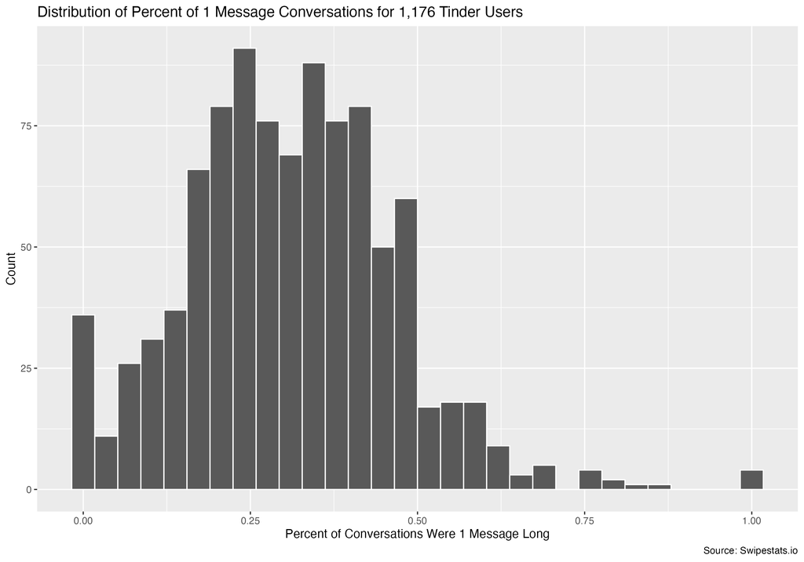

Percent of 1 Message Conversations Histogram

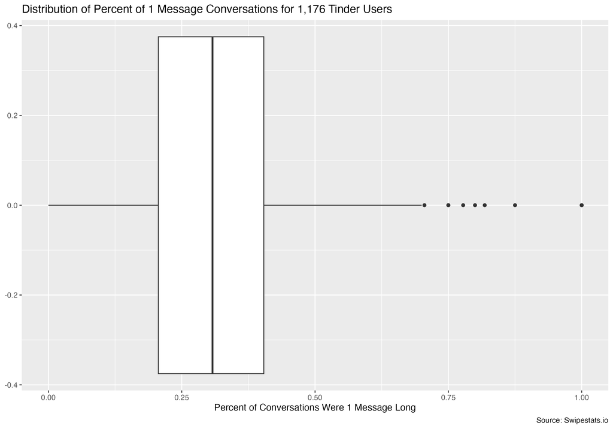

Percent of 1 Message Conversations Boxplot

```r
# step 1: remove no conversation users
tinder_data_clean <-
  tinder_data |>
  filter(longest_convo_msgs != 0)

# step 2: create a new variable to show percent of user conversations that
# were 1 message long
tinder_data_clean <-
  tinder_data_clean |>
    mutate(
      pct_one_msg = number_one_msg_conversations / number_conversations
    )

# step 3: summary stats
skim_without_charts(tinder_data_clean$pct_one_msg)
```

Data summary

| Name | tinder_data_clean$pct_one… |
| --- | --- |
| Number of rows | 1176 |
| Number of columns | 1 |
| _______________________ |  |
| Column type frequency: |  |
| numeric | 1 |
| ________________________ |  |
| Group variables | None |

**Variable type: numeric**

| skim_variable | n_missing | complete_rate | mean | sd | p0 | p25 | p50 | p75 | p100 |
| --- | --- | --- | --- | --- | --- | --- | --- | --- | --- |
| data | 0 | 1 | 0.32 | 0.18 | 0 | 0.2 | 0.31 | 0.42 | 1 |

For 1,176 active Tinder users, the median percent of 1 message conversations per user was approximately 30%. The distribution of percent of conversations lasting 1 message for these active users is skewed right. Users had percentage of conversations lasting 1 message ranging from 0 to 100%. Users with 100% of their conversations lasting 1 message appear to be outliers. This distribution examined the percent of individual user conversations that lasted one message *instead* of examining the percent of overall conversations that lasted 1 message because variations in individual activity needed to be accounted for. One user might have used Tinder very often and had a high percentage of their message activity being one message conversations. While another might have used Tinder infrequently, choosing to message very few people for longer durations.

### Objective 2

Determine who is most “popular/liked”.

**Solution**

```r
tinder_data_clean <-
  tinder_data_clean |>
  filter(matches != 0) |>
  mutate(
    ratio_matches_to_likes = matches / swipes_like
  )

top_matches <-
  tinder_data_clean |>
  arrange(desc(matches)) |>
  slice_head(n = 5)

top_matches <-
  top_matches |>
  select(user_id, user_gender, matches:swipes_pass, ratio_matches_to_likes)

top_matches <- janitor::clean_names(top_matches, "title")

kable(top_matches)
```

| User Id | User Gender | Matches | Swipes Like | Swipes Pass | Ratio Matches to Likes |
| --- | --- | --- | --- | --- | --- |
| 160dae1bf017f6109584bc5d11595428 | M | 23758 | 198373 | 41303 | 0.1197643 |
| cef50ce50692bb1260ae383c8e2a029c | M | 22120 | 229162 | 363855 | 0.0965256 |
| 3c159947bd2b43b5983d9e5b01b136be | M | 16048 | 290148 | 188536 | 0.0553097 |
| de14c049d9bc38720b566ac98a1f3998 | F | 14874 | 19449 | 108536 | 0.7647694 |
| 16a22fdad3de24d72d8509711c454ffb | M | 13104 | 208304 | 195912 | 0.0629081 |

These “most popular” users do not account for the fact that different users might use the app differently. Some might not be super active on the app, but when they are they receive a lot of attention. Some of these users might have received the “most matches” because they simply sue the app more than others. Additionally, matches rely on both users liking each other. Some users might be very picky and pass on most people, despite receiving a lot of likes.

A way to account for this is examining the ratio of matches to likes sent. This would take into account different approaches to using the app (including different standards for likes and amounts of account activity).

```r
top_matches_normalized <-
  tinder_data_clean |>
  arrange(desc(ratio_matches_to_likes)) |>
  slice_head(n =5)

top_matches_normalized <-
  top_matches_normalized |>
  select(user_id, user_gender, matches:swipes_pass, ratio_matches_to_likes)

top_matches_normalized <- janitor::clean_names(top_matches_normalized, "title")

kable(top_matches_normalized)
```

| User Id | User Gender | Matches | Swipes Like | Swipes Pass | Ratio Matches to Likes |
| --- | --- | --- | --- | --- | --- |
| d81b5d32c63759d8a91b6ca430e45748 | F | 826 | 956 | 8064 | 0.8640167 |
| 6e4e15e49bacb7c95af50673553f171c | F | 26 | 33 | 1606 | 0.7878788 |
| 258e1114a845d94aa20cce699002c4c5 | F | 137 | 177 | 18374 | 0.7740113 |
| de14c049d9bc38720b566ac98a1f3998 | F | 14874 | 19449 | 108536 | 0.7647694 |
| 8077faeaa4104af4f88db4c660e90371 | F | 624 | 829 | 17141 | 0.7527141 |

Looking at the two results, it is clear that using “matches” as a metric for most popular on the Tinder app is not accurate. When using matches as our criteria, only one of the top 5 “most popular” users receives a match back more than 50% of the time. Most of the other top users do not even receive a match back 10% of the time. These top 5 users might appear most popular because they use the app more often or tend to send likes more often than others do.

Looking at the normalized matches, we see that the ratio of matches to likes sent more accurately reflects whether a user is more popular on the Tinder app. All 5 of the “most popular” users receive a match back more than 75% of the time. These users have varying levels of activity, with some sending only a total of 33 likes and others a total of 19449 likes. Only one user is found in common for both criteria, with a match to like ratio of approximately .76 and total matches 14874.